# Ethogram Data Collection 1 - Outcome (Success, Fail)

Marinara Marcato

# 1 Introduction

This document shows the data analysis carried out to investigate the association between ethogram scores filled out by two trainers and the dog’s training outcome. Statistical methods will be used to test the hypothesis that there is a relationship between ethogram scores at DC1 and training outcome (Success, Fail).

# 2 Data Exploration

The dataset comprised of the following types and number of variables. The original ethogram items contained ordinal and categorical variables. The score variables were numerical derived from the original ethogram items.

```
##
## categorical    comments        info     ordinal       score        time
##          17          16          17          53          42          25
##      unused
##          11
```

All ordinal (N = 53) and categorical (N = 17) variables from the original ethogram items, score (N = 42) variables derived from the original ethogram items and demographical variables (N = 2) - namely, Sex and Breed - will be analysed.

## 2.1 Demographics

Overview of the dogs participating in the data collection. Inclusion criteria: only Labrador Retrievers (LR) and Labrador Retrievers crossed with Golden Retrievers (LRxGR) were kept for data analysis.

```
## Original dataset (dogs, variables):  101 133
```

```
##
##        GR GRxPoodle        LR       LRx     LRxGR
##         1         1        45        13        41
```

```
##
##    LR LRxGR
##    45    54
```

```
## Final dataset (dogs, variables):  99 133
```

```
##
## Success    Fail
##      79      20
```

```
##
##   Success      Fail
## 0.7979798 0.2020202
```

```
##
##  F  M
## 49 50
```

Calculate descriptive statistics for age at arrival at the training centre for formal training. Calculate descriptive statistics for age at assessment when the dogs performed the behaviour test at data collection 1, which should be around week 3 of formal training.

```
## Age at Arrival: Mean 15.26 Standard Deviation 2.03 Minimum: 12.3 Maximum: 21.9
```

```
## Age at Assessment: Mean 16.12 Standard Deviation 2.01 Minimum: 12.99 Maximum: 22.62
```

Calculate statistics of duration of training for the dogs that were withdrawn from training. Performing this behaviour test at the beginning on the training (Week 3) would allow assistance dog training organisations to understand which dog are more suitable and allow them to make informed decisions when analysing which dogs to keep for training considering the results of this objective assessment.

```
## [1] "Duration of Training in weeks"
```

```
##     Duration
##  Min.   : 1.143
##  1st Qu.: 9.000
##  Median :14.429
##  Mean   :15.064
##  3rd Qu.:18.357
##  Max.   :31.143
```

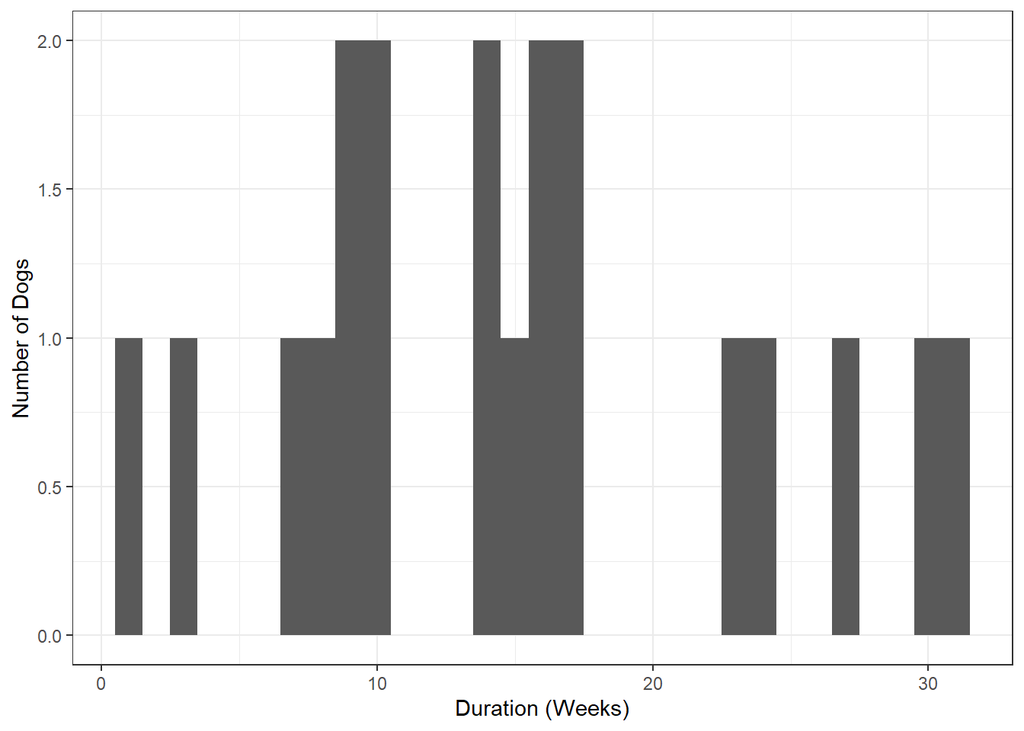

## 2.2 Descriptive Statistics

```
##                                                  Min.  X1st.Qu.     Median
## Familiarisation.Response..Oriented.to.Handler.   1.00  1.750000   2.000000
## Familiarisation.Response..Exploration.           1.00  4.000000   5.000000
## Familiarisation.Response..Waiting.               1.00  1.000000   1.000000
## Call.Back.Response                               1.00  1.000000   1.000000
## Walking.Distractibility                          1.00  1.000000   2.000000
## Walking.Pull.on.leash                            1.00  1.000000   2.000000
## Walking.Pull.strength                            1.00  1.000000   1.000000
## Walking.Initiative                               1.00  2.000000   2.000000
## Standing.Response                                1.00  2.000000   2.000000
## Sitting.Response                                 1.00  2.000000   3.000000
## Lying.Response                                   1.00  2.000000   3.000000
## Lying.Settled                                    1.00  1.000000   2.000000
## Body.check.Table                                 1.00  3.000000   4.000000
## Body.check.Response                              1.00  3.000000   3.000000
## Distractions.First.Response..Teddy.              1.00  3.000000   4.000000
## Distractions.First.Response..Human.              2.00  3.000000   3.000000
## Distractions.First.Response..Car.                1.00  2.500000   3.000000
## Distractions.First.Response..Food.               1.00  4.000000   4.000000
## Distractions.Second.Response..Teddy.             1.00  2.000000   3.000000
## Distractions.Second.Response..Human.             1.00  2.000000   3.000000
## Distractions.Second.Response..Car.               1.00  2.000000   3.000000
## Distractions.Second.Response..Food.              1.00  3.000000   4.000000
## Distractions.Pull.on.leash                       1.00  3.000000   3.000000
## Distractions.Human                               3.00  4.000000   5.000000
## Kong.Presentation.Response                       1.00  2.000000   4.000000
## Kong.Interaction.Response.to.stimulus            1.00  3.000000   3.000000
## Kong.Interaction.Response.to.handler             1.00  1.000000   1.000000
## Kong.Interaction.Back                            1.00  1.000000   1.000000
## Kong.Return.Handler                              1.00  2.000000   2.000000
## Dog.Response                                     1.00  4.000000   5.000000
## Dog.Call.Back.Response                           1.00  1.000000   2.000000
## Crate.Entering                                   1.00  1.000000   1.000000
## Crate.Behaviours..Settled.                       1.00  1.000000   2.000000
## Crate.Behaviours..Sniffing.Exploring..           1.00  2.000000   3.000000
## Crate.Behaviours..Actively.Seeking.Attention.    1.00  1.000000   1.000000
## Crate.Behaviours..Digging.                       1.00  1.000000   1.000000
## Crate.Behaviours..Whining.                       1.00  1.000000   1.000000
## Crate.Behaviours..Barking.                       1.00  1.000000   1.000000
## Crate.Self.Modulation                            1.00  1.000000   2.000000
```

[output cut: 236 more lines]

```
## S.Crate.Stimulus_mean                            3.250000    2
## S.Crate.Stimulus_prod                          108.000000    0
## S.Crate.Handler_mean                             4.000000    2
## S.Crate.Handler_prod                            60.000000    0
## S.Petting.Stimulus.During_mean                   4.000000    1
## S.Petting.Stimulus.During_prod                  15.000000    0
## S.Petting.Engagement.During_mean                 3.500000    1
## S.Petting.Engagement.During_prod                10.000000    0
## S.Petting.After_mean                             3.500000    1
## S.Petting.After_prod                            12.000000    0
## S.Isolation.Handler_mean                         4.333333    1
## S.Isolation.Handler_prod                        75.000000    0
## S.Isolation.Stimulus                             3.000000    1
## S.Sociability_mean                               5.333333    0
## S.Sociability_prod                             150.000000    0
```

```
## dataframe saved to  3_analysis/dc1-new/descriptive-statistics-numerical.csv
```

```
##                                                                  No Yes NA.s
## Body.check.General..Mouths.                                      95   3    1
## Body.check.General..Licks.                                       84  14    1
## Tea.Towel.First.Response..Indifferent.                           88  10    1
## Tea.Towel.First.Response..Change.from.Neutral.                   13  85    1
## Tea.Towel.First.Response..Turns.head.                            17  81    1
## Tea.Towel.First.Response..Attempts.to.Removes.towel.by.moving.   47  51    1
## Tea.Towel.First.Response..Attempts.to.Removes.towel.with.mouth.  52  46    1
## Tea.Towel.First.Response..Plays.                                 88  10    1
## Tea.Towel.Second.Response..Indifferent.                          72  24    3
## Tea.Towel.Second.Response..Turns.head.                           31  65    3
## Tea.Towel.Second.Response..Change.from.Neutral.                  26  70    3
## Tea.Towel.Second.Response..Attempts.to.Removes.towel.by.moving.  50  46    3
## Tea.Towel.Second.Response..Attempts.to.Removes.towel.with.mouth. 58  38    3
## Tea.Towel.Second.Response..Plays.                                83  13    3
## Crate.Urinating                                                  95   2    2
## Isolation.Urinating                                              98   1    1
```

```
## dataframe saved to  3_analysis/dc1-new/descriptive-statistics-ordinal.csv
```

```
## dataframe saved to  3_analysis/dc1-new/kong-lateralisation.csv
```

## 2.3 Feature Selection

Metholodogy adapted from Hosmer2013, pg 107 (GLOW study example).

### 2.3.1 Step 1: Univariate logistic regression model results.

Features which achieved P < 0.25 were selected for consideration to be included in the reduced feature set. Subsequentely, related variables were removed considering two cases: - Two scores: when both the mean and product scores were selected, the score with the highest p-value was removed. - Score and original items: when both the original item and the score derived from it were selected, the one with the highest p-value was removed.

```
## Categorical variable with 4 factors: Both Left None Righ
```

```
## $Kong.Interaction.Lateralisation
##
## Call:
## glm(formula = Outcome ~ x, family = binomial(link = logit), data = dc_cat,
##     na.action = na.exclude)
##
## Deviance Residuals:
##     Min       1Q   Median       3Q      Max
## -0.8346  -0.7981  -0.5482  -0.4590   2.1460
##
## Coefficients:
##             Estimate Std. Error z value Pr(>|z|)
## (Intercept)  -2.1972     1.0540  -2.085   0.0371 *
## xLeft         1.3218     1.1808   1.119   0.2630
## xNone         0.3781     1.1422   0.331   0.7406
## xRigh         1.2164     1.1576   1.051   0.2934
## ---
## Signif. codes:  0 '***' 0.001 '**' 0.01 '*' 0.05 '.' 0.1 ' ' 1
##
## (Dispersion parameter for binomial family taken to be 1)
##
##     Null deviance: 90.954  on 91  degrees of freedom
## Residual deviance: 87.635  on 88  degrees of freedom
##   (7 observations deleted due to missingness)
## AIC: 95.635
##
## Number of Fisher Scoring iterations: 4
```

Save results from univariate analysis.

```
## dataframe saved to  3_analysis/dc1-new/univariate-logistic regression.csv.csv
```

```
## dataframe saved to  3_analysis/dc1-new/significant-variables-25.csv.csv
```

**Variables with p < 0.25 (N = 28): original (N = 13), scores (N = 15) some are repeated**, **after removing related variables (N = 13): original (N = 9), scores (N = 4)**.

Variables whose logistic regression model resulted in p<0.25 when used to predict Outcome are shown.

```
##                                                                  p_value_1
## Tea.Towel.Second.Response..Turns.head.                          0.24842262
## Tea.Towel.First.Response..Attempts.to.Removes.towel.with.mouth. 0.23443761
## Isolation.Response..Unsettled.Pacing.                           0.21850000
## S.Kong.Response_prod                                            0.19760000
## Lying.Settled                                                   0.19500000
## S.Walking.Distractions.Pull_prod                                0.17730000
## Petting.Responsiveness.After                                    0.17540000
## Crate.Behaviours..Actively.Seeking.Attention.                   0.15560000
## S.Crate.Stimulus_mean                                           0.12230000
## Tea.Towel.First.Response..Indifferent.                          0.11768247
## Breed                                                           0.05448661
## Petting.Confidence.During                                       0.04350000
## S.Sensitivity_mean                                              0.00570000
```

```
##  [1] "Lying.Settled"
##  [2] "Crate.Behaviours..Actively.Seeking.Attention."
##  [3] "Petting.Confidence.During"
##  [4] "Petting.Responsiveness.After"
##  [5] "Isolation.Response..Unsettled.Pacing."
##  [6] "S.Walking.Distractions.Pull_prod"
##  [7] "S.Sensitivity_mean"
##  [8] "S.Kong.Response_prod"
##  [9] "S.Crate.Stimulus_mean"
## [10] "Tea.Towel.First.Response..Indifferent."
## [11] "Tea.Towel.First.Response..Attempts.to.Removes.towel.with.mouth."
## [12] "Tea.Towel.Second.Response..Turns.head."
## [13] "Breed"
## [14] "Outcome"
```

### 2.3.2 Step 2: Correlation

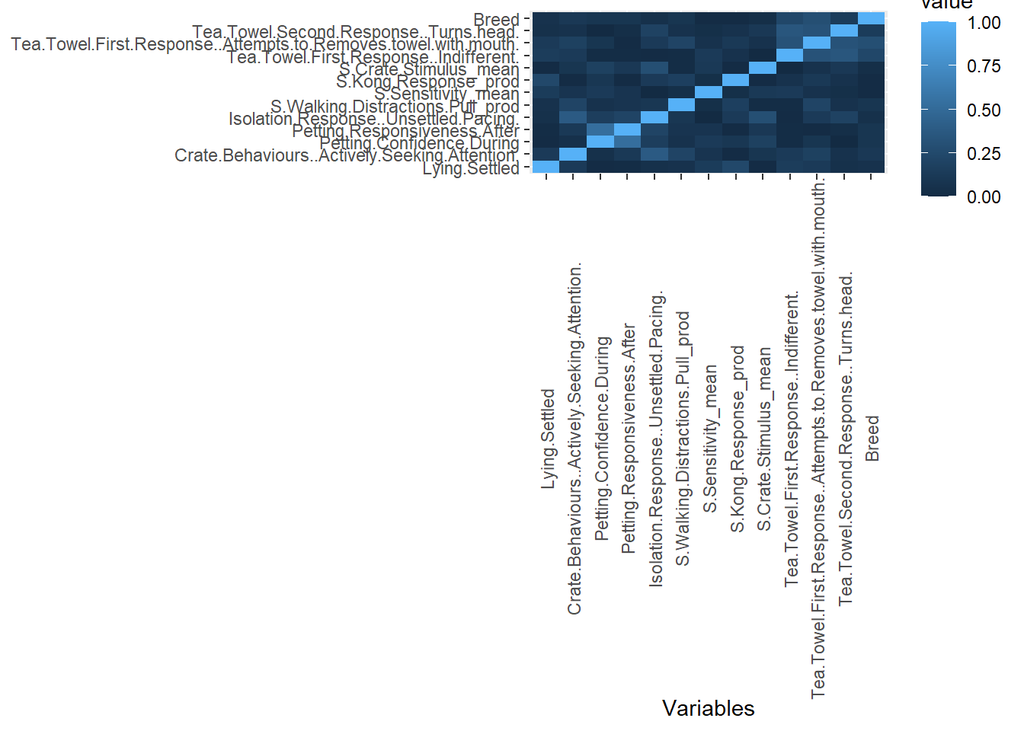

```
## [1] "Petting.Confidence.During"
```

### 2.3.3 Step 2: Multivariate model

The first multivariate model was built using the features selected in the step above. Then, the feature with the highest p-value above 5% significance level in the multivariate model was removed from the dataset. Another multivariate model was built with the new dataset and the procedure was repeated until no feature had a p-value above 5%. The difference in deviance was monitored to make sure the variable did not significantly affect model fitness.

```
##  [1] "Lying.Settled"
##  [2] "Crate.Behaviours..Actively.Seeking.Attention."
##  [3] "Petting.Responsiveness.After"
##  [4] "Isolation.Response..Unsettled.Pacing."
##  [5] "S.Walking.Distractions.Pull_prod"
##  [6] "S.Sensitivity_mean"
##  [7] "S.Kong.Response_prod"
##  [8] "S.Crate.Stimulus_mean"
##  [9] "Tea.Towel.First.Response..Indifferent."
## [10] "Tea.Towel.First.Response..Attempts.to.Removes.towel.with.mouth."
## [11] "Tea.Towel.Second.Response..Turns.head."
## [12] "Breed"
## [13] "Outcome"
```

```
## [1] "Initial multivariate model"
```

```
##
## Call:
## glm(formula = Outcome ~ ., family = binomial(link = logit), data = data_2)
##
## Deviance Residuals:
##     Min       1Q   Median       3Q      Max
## -1.6172  -0.5276  -0.3096  -0.1005   1.9843
##
## Coefficients:
##                                                                     Estimate
## (Intercept)                                                         1.242885
## Lying.Settled                                                       0.630414
## Crate.Behaviours..Actively.Seeking.Attention.                      -0.568005
## Petting.Responsiveness.After                                       -0.428697
## Isolation.Response..Unsettled.Pacing.                               0.638835
## S.Walking.Distractions.Pull_prod                                   -0.133292
## S.Sensitivity_mean                                                 -2.602419
## S.Kong.Response_prod                                                0.018892
## S.Crate.Stimulus_mean                                               0.356098
## Tea.Towel.First.Response..Indifferent.Yes                           1.302495
## Tea.Towel.First.Response..Attempts.to.Removes.towel.with.mouth.Yes -0.194473
## Tea.Towel.Second.Response..Turns.head.Yes                           1.353040
## BreedLRxGR                                                         -0.861684
##                                                                    Std. Error
## (Intercept)                                                          3.151049
## Lying.Settled                                                        0.411432
## Crate.Behaviours..Actively.Seeking.Attention.                        0.356970
## Petting.Responsiveness.After                                         0.475357
## Isolation.Response..Unsettled.Pacing.                                0.417300
## S.Walking.Distractions.Pull_prod                                     0.085819
## S.Sensitivity_mean                                                   1.199219
## S.Kong.Response_prod                                                 0.006721
## S.Crate.Stimulus_mean                                                0.987463
## Tea.Towel.First.Response..Indifferent.Yes                            1.291372
## Tea.Towel.First.Response..Attempts.to.Removes.towel.with.mouth.Yes   0.847111
## Tea.Towel.Second.Response..Turns.head.Yes                            0.967077
## BreedLRxGR                                                           0.791382
##                                                                    z value
## (Intercept)                                                          0.394
## Lying.Settled                                                        1.532
```

[output cut: 21 more lines]

```
## Tea.Towel.First.Response..Indifferent.Yes                           0.31316
## Tea.Towel.First.Response..Attempts.to.Removes.towel.with.mouth.Yes  0.81842
## Tea.Towel.Second.Response..Turns.head.Yes                           0.16178
## BreedLRxGR                                                          0.27623
## ---
## Signif. codes:  0 '***' 0.001 '**' 0.01 '*' 0.05 '.' 0.1 ' ' 1
##
## (Dispersion parameter for binomial family taken to be 1)
##
##     Null deviance: 83.449  on 87  degrees of freedom
## Residual deviance: 57.748  on 75  degrees of freedom
##   (11 observations deleted due to missingness)
## AIC: 83.748
##
## Number of Fisher Scoring iterations: 6
```

```
##
## Call:
## glm(formula = Outcome ~ ., family = binomial(link = logit), data = data_3)
##
## Deviance Residuals:
##     Min       1Q   Median       3Q      Max
## -1.1772  -0.6017  -0.4352  -0.2240   2.3294
##
## Coefficients:
##                                                Estimate Std. Error z value
## (Intercept)                                    1.485692   1.519917   0.977
## Crate.Behaviours..Actively.Seeking.Attention. -0.671372   0.299115  -2.245
## Isolation.Response..Unsettled.Pacing.          0.716168   0.324408   2.208
## S.Sensitivity_mean                            -2.341442   0.949035  -2.467
## S.Kong.Response_prod                           0.010581   0.004934   2.145
##                                               Pr(>|z|)
## (Intercept)                                     0.3283
## Crate.Behaviours..Actively.Seeking.Attention.   0.0248 *
## Isolation.Response..Unsettled.Pacing.           0.0273 *
## S.Sensitivity_mean                              0.0136 *
## S.Kong.Response_prod                            0.0320 *
## ---
## Signif. codes:  0 '***' 0.001 '**' 0.01 '*' 0.05 '.' 0.1 ' ' 1
##
## (Dispersion parameter for binomial family taken to be 1)
##
##     Null deviance: 92.237  on 94  degrees of freedom
## Residual deviance: 76.719  on 90  degrees of freedom
##   (4 observations deleted due to missingness)
## AIC: 86.719
##
## Number of Fisher Scoring iterations: 5
```

```
## [1] "Crate.Behaviours..Actively.Seeking.Attention."
## [2] "Isolation.Response..Unsettled.Pacing."
## [3] "S.Sensitivity_mean"
## [4] "S.Kong.Response_prod"
## [5] "Outcome"
```

## 2.4 Missing Data

DC1, missing values per column and per row. Very few data are missing considering the original items selected.

```
## Crate.Behaviours..Actively.Seeking.Attention.
##                                             3
##         Isolation.Response..Unsettled.Pacing.
##                                             1
##                            S.Sensitivity_mean
##                                             0
##                          S.Kong.Response_prod
##                                             0
##                                       Outcome
##                                             0
```

```
## dc_row_nas
##  0  1
## 95  4
```

## 2.5 Visualization

```
## Plot these features manually:
```

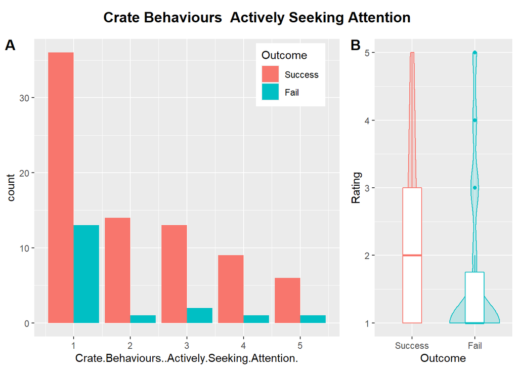

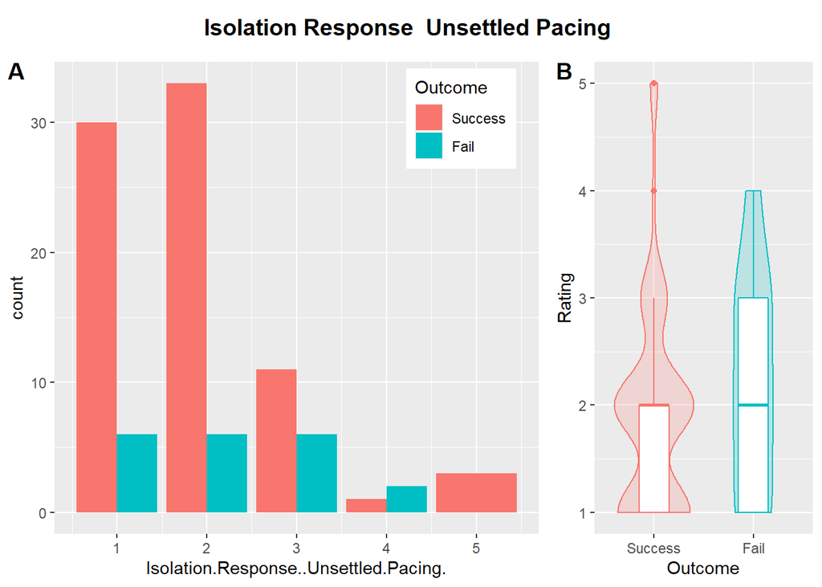

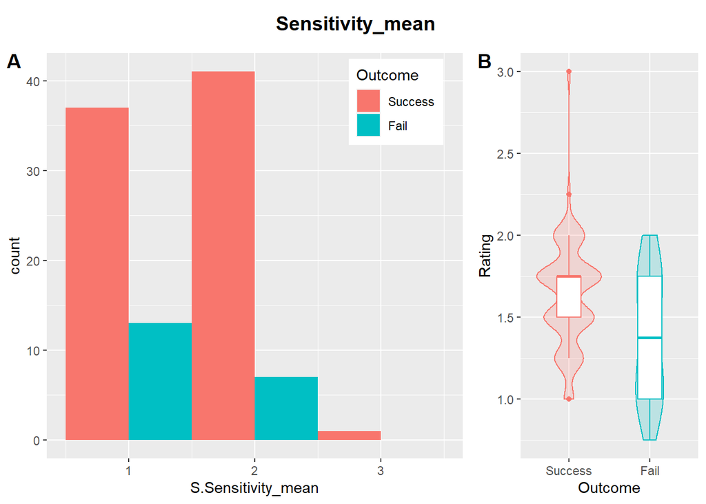

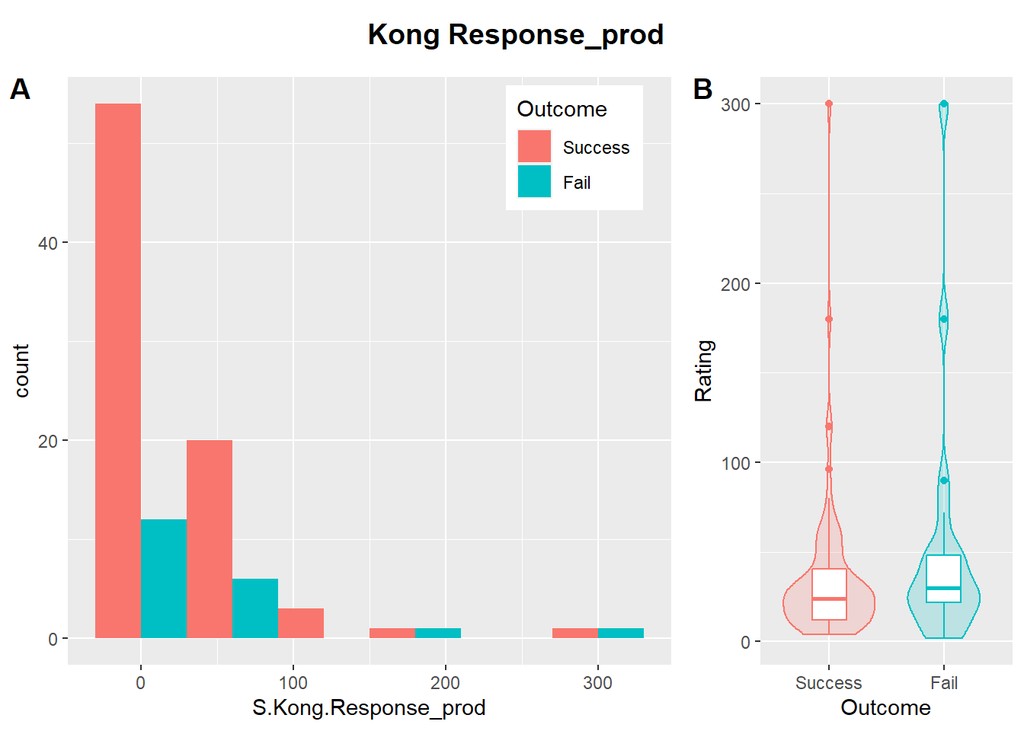

# 3 Multivariate Model

## 3.1 Preprocessing: Normalization + Imputation + PCA

## 3.2 Recursive Feature Elimination (RFE) + Multivariate Logistic Regression (LR)

Build model.

```
## [1] "Crate.Behaviours..Actively.Seeking.Attention."
## [2] "Isolation.Response..Unsettled.Pacing."
## [3] "S.Sensitivity_mean"
## [4] "S.Kong.Response_prod"
## [5] "Outcome"
```

```
## predicting second class: Fail Success
```

```
##
## Recursive feature selection
##
## Outer resampling method: Cross-Validated (99 fold)
##
## Resampling performance over subset size:
##
##  Variables AUC Precision Recall F AUCSD PrecisionSD RecallSD FSD Num_Resamples
##          1 NaN    0.5714    0.2 1    NA      0.5345   0.4104   0            99
##          2 NaN    0.5000    0.2 1    NA      0.5345   0.4104   0            99
##          3 NaN    0.6667    0.3 1    NA      0.5000   0.4702   0            99
##          4 NaN    0.6667    0.3 1    NA      0.5000   0.4702   0            99
##  Selected
##
##
##         *
##
##
## The top 3 variables (out of 3):
##    PC4, PC3, PC2
```

```
##
## Call:
## glm(formula = Class ~ ., family = "binomial", data = tmp)
##
## Deviance Residuals:
##     Min       1Q   Median       3Q      Max
## -2.4548   0.2075   0.4102   0.6286   1.2740
##
## Coefficients:
##             Estimate Std. Error z value Pr(>|z|)
## (Intercept)   1.8070     0.3427   5.273 1.34e-07 ***
## PC4          -1.3472     0.4306  -3.128  0.00176 **
## PC3          -0.7208     0.2879  -2.504  0.01229 *
## PC2          -0.4313     0.2520  -1.711  0.08700 .
## ---
## Signif. codes:  0 '***' 0.001 '**' 0.01 '*' 0.05 '.' 0.1 ' ' 1
##
## (Dispersion parameter for binomial family taken to be 1)
##
##     Null deviance: 99.632  on 98  degrees of freedom
## Residual deviance: 79.735  on 95  degrees of freedom
## AIC: 87.735
##
## Number of Fisher Scoring iterations: 5
```

Model fitness with deviance analysis. Performance metrics ROC and PR curves.

```
##
## deviance difference:  19.89629
```

```
##
## df difference:  3
```

```
##
## level of significance:  0.0001783528
```

```
##
## the model is a good fit:  TRUE
```

```
## Confusion Matrix and Statistics
##
##           Reference
## Prediction Fail Success
##    Fail       6       3
##    Success   14      76
##
##                Accuracy : 0.8283
##                  95% CI : (0.7394, 0.8967)
##     No Information Rate : 0.798
##     P-Value [Acc > NIR] : 0.27089
##
##                   Kappa : 0.3297
##
##  Mcnemar's Test P-Value : 0.01529
##
##             Sensitivity : 0.30000
##             Specificity : 0.96203
##          Pos Pred Value : 0.66667
##          Neg Pred Value : 0.84444
##              Prevalence : 0.20202
##          Detection Rate : 0.06061
##    Detection Prevalence : 0.09091
##       Balanced Accuracy : 0.63101
##
##        'Positive' Class : Fail
##
```

```
##
##   ROC curve
##
##     Area under curve:
##      0.6905063
##
##     Curve for scores from  0.004766535  to  0.7890231
##     ( can be plotted with plot(x) )
```

```
## Confusion Matrix and Statistics
##
##           Reference
## Prediction Fail Success
##    Fail       6       3
##    Success   14      76
##
##                Accuracy : 0.8283
##                  95% CI : (0.7394, 0.8967)
##     No Information Rate : 0.798
##     P-Value [Acc > NIR] : 0.27089
##
##                   Kappa : 0.3297
##
##  Mcnemar's Test P-Value : 0.01529
##
##               Precision : 0.66667
##                  Recall : 0.30000
##                      F1 : 0.41379
##              Prevalence : 0.20202
##          Detection Rate : 0.06061
##    Detection Prevalence : 0.09091
##       Balanced Accuracy : 0.63101
##
##        'Positive' Class : Fail
##
```

```
##
##   Precision-recall curve
##
##     Area under curve (Integral):
##      0.4393922
##
##     Area under curve (Davis & Goadrich):
##      0.4383627
##
##     Curve for scores from  0.004766535  to  0.7890231
##     ( can be plotted with plot(x) )
```

Plots the logit function

```
## [1] "Probability predicted by the LR using PRQ data vs true Outcome"
```

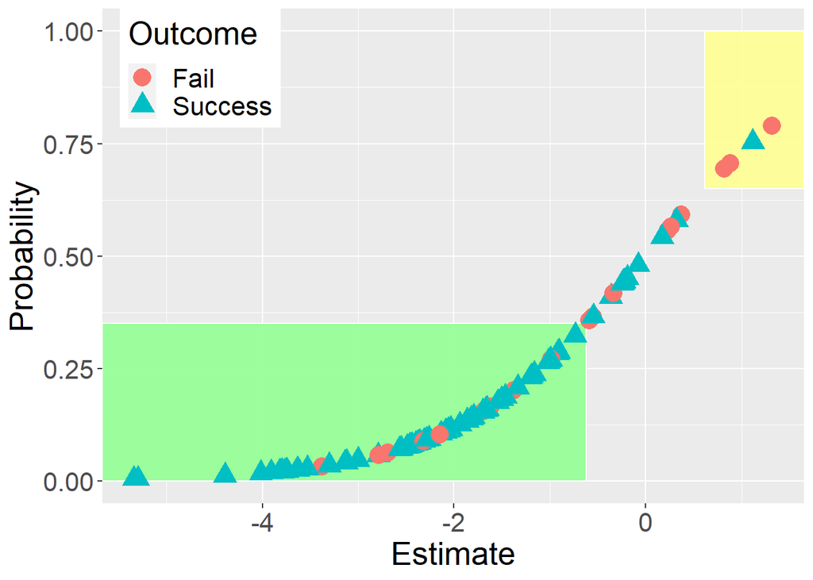

```
## [1] "Probability predicted by the LR using PRQ data vs true Status"
```

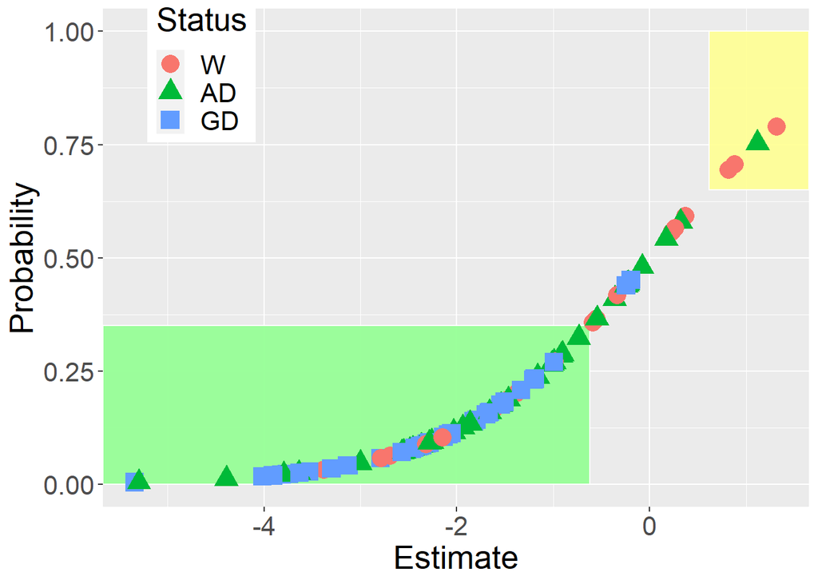

```
## [1] "Estimate and Probabilities per training outcome status"
```

```
## # A tibble: 3 × 2
##   Status  Mean
##   <fct>  <dbl>
## 1 W      -1.02
## 2 AD     -1.59
## 3 GD     -2.40
```

```
## # A tibble: 3 × 2
##   Status  Mean
##   <fct>  <dbl>
## 1 W      0.323
## 2 AD     0.236
## 3 GD     0.115
```

```
## Predicted probability < 0.35  -> Green flag
```

```
## [1] "Dogs flagged green are likely to SUCCEED, true outcome count and status proportion:"
```

```
##
##    Fail Success
##      11      67
```

```
##
##         W        AD        GD
## 0.1410256 0.3333333 0.5256410
```

```
## Predicted probability > 0.65 -> Yellow flag
```

[output not shown]

```
##
##    Fail Success
##       3       1
```

```
##
##    Fail Success
##    0.75    0.25
```

```
##
##    W   AD   GD
## 0.75 0.25 0.00
```

```
## 0.35  < Predicted probability < 0.65 -> no flags
```

```
##
##  W AD GD
##  6  9  2
```

```
##
##         W        AD        GD
## 0.3529412 0.5294118 0.1176471
```

Check the dogs that were false positives or false negatives

```
## [1] 59 47 21
```

```
## [1] Ozark Katie Gav
## 101 Levels: Clay Diva Dora Douglas Dugg Earl Ebbi Eddie Edrick Effie ... Zodiac
```

```
##  [1] 17 50 72  3 89 97 22 53 19 44 68  9 39  2
```

[output not shown]

## 3.3 Interpretation

```
## [1] "Results from the model created"
```

```
##               Estimate Std. Error   z value     Pr(>|z|)        OR     2.5 %
## (Intercept)  1.8069686  0.3426513  5.273492 1.338524e-07 6.0919522 3.3023078
## PC4         -1.3471702  0.4306427 -3.128278 1.758337e-03 0.2599749 0.1040066
## PC3         -0.7208293  0.2879165 -2.503605 1.229351e-02 0.4863488 0.2673052
## PC2         -0.4312996  0.2520099 -1.711439 8.700010e-02 0.6496642 0.3870025
##                 97.5 %
## (Intercept) 12.8833667
## PC4          0.5732418
## PC3          0.8444906
## PC2          1.0554959
```

```
## dataframe saved to  3_analysis/dc1-new/rfe-lr.csv
```

## 3.4 Feature Importance

### 3.4.1 Explained variance

```
## PCA features kept in the final model after RFE:  (Intercept) PC4 PC3 PC2
```

```
## [1] "Explained Variance per Principal Component (Scree Plot)"
```

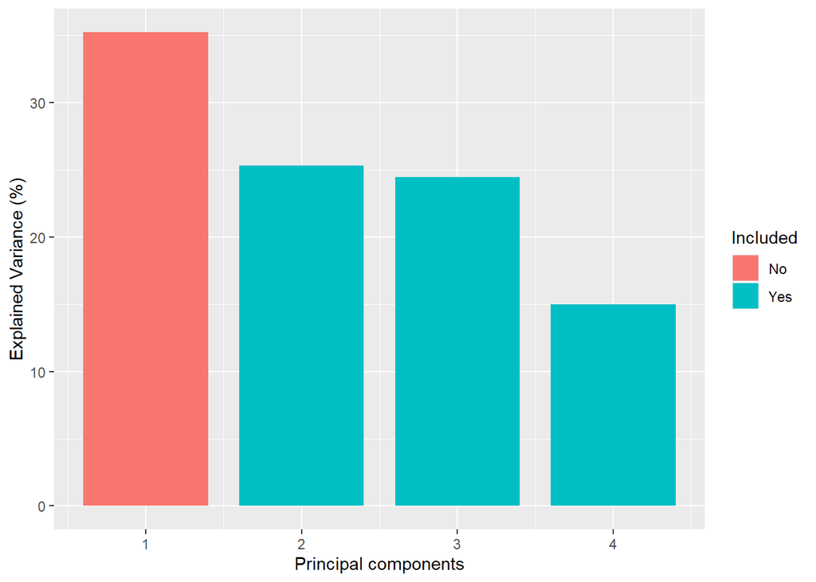

### 3.4.2 Coefficient loadings

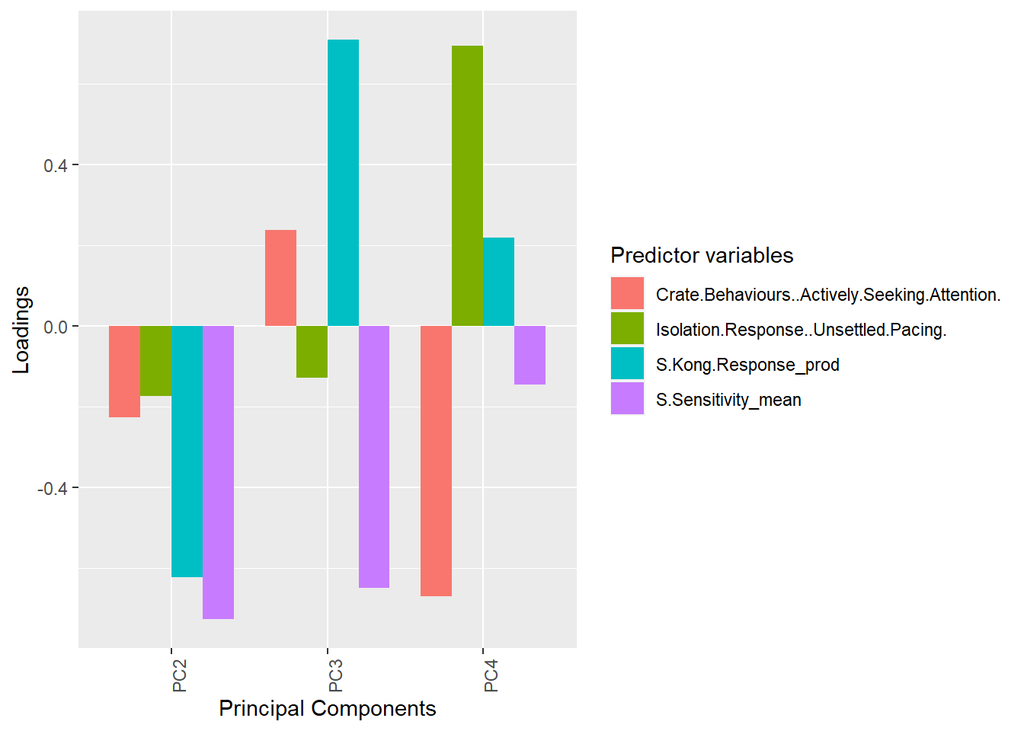

```
## dataframe saved to  3_analysis/dc1-new/pc-loading.csv
```

```
## [[1]]
##                                           terms      value
## 1         Isolation.Response..Unsettled.Pacing.  0.6937907
## 2 Crate.Behaviours..Actively.Seeking.Attention. -0.6706547
## 3                          S.Kong.Response_prod  0.2188101
## 4                            S.Sensitivity_mean -0.1449100
##
## [[2]]
##                                           terms      value
## 1                          S.Kong.Response_prod  0.7094716
## 2                            S.Sensitivity_mean -0.6504539
## 3 Crate.Behaviours..Actively.Seeking.Attention.  0.2385841
## 4         Isolation.Response..Unsettled.Pacing. -0.1289860
##
## [[3]]
##                                           terms      value
## 1                            S.Sensitivity_mean -0.7281098
## 2                          S.Kong.Response_prod -0.6231377
## 3 Crate.Behaviours..Actively.Seeking.Attention. -0.2262517
## 4         Isolation.Response..Unsettled.Pacing. -0.1742576
```

# 4 Conclusion